# Natural Events - Health & Economic Impact

# Summary / Research Question

Storms and other severe weather events cause both public health and economic problems. Severe events result in fatalities, injuries, property and crop damage. In the follwing I have explored the U.S. National Oceanic and Atmospheric Administration’s (NOAA) storm database to determine, which types of events

- are most harmful with respect to population health, expressed in fatalities, and injuries?
- have the greatest economic consequences, expressed in property and crop damage?

The answers to both questions are given by tables with top 1o natural disaster events, and graphics that show, over the time period from 1950 and end in November 2011, the accumulated health and economic impact.

# Data Fetching

#### Data Download & Ingestion

```r
# set work directory
setwd("/Users/joergheintz/Documents/08_MPHPHI/11_Coursera/Coursera_ReproduciableResearch/RepResProj2")

#data download from the source
mypath<-"https://d396qusza40orc.cloudfront.net/repdata%2Fdata%2FStormData.csv.bz2"
download.file(mypath,"myfile.bz2")

# read file, and extract needed variables
mydata<-read.csv("myfile.bz2")[,c("STATE", "EVTYPE", "FATALITIES", "INJURIES", "PROPDMG", "PROPDMGEXP", "CROPDMG", "CROPDMGEXP", "BGN_DATE")]
```

#### Cleaning & Restructure Date

```r
# Split date from time, keep date
BGN_DATE<-data.frame(t(as.data.frame(strsplit(as.character(mydata$BGN_DATE),' ')))[,1], row.names=NULL)
mydata$BGN_DATE<-as.Date(mydata$BGN_DATE, "%m/%d/%Y")
```

#### Split data set into Fatalities/Injuiries and Property/Crop Damage

The splited data sets, one for health, and other for economic are stored locally.

```r
# Fatalities & Injuries
df_FAT_INJ<-mydata[mydata$FATALITIES != 0 | mydata$INJURIES != 0 ,c("STATE", "EVTYPE", "FATALITIES", "INJURIES", "BGN_DATE")]
write.csv(df_FAT_INJ, "FAT_INJ.csv")

# Property & Crop Damage
df_ECO_DAM<-mydata[mydata$PROPDMG != 0 | mydata$CROPDMG, c("STATE", "EVTYPE", "PROPDMG", "PROPDMGEXP", "CROPDMG", "CROPDMGEXP", "BGN_DATE") ]
write.csv(df_ECO_DAM, "ECO_DAM.csv")
```

# Data Processing

The data processing sections accumulate the values from date to date (incremental). The following steps have been taken:

1. Top 10 event calculation (using tapply, grouped by events)
2. Calculation of the time series of the top 5 events, plot preperation.
3. Generating top 5 event plots. The plots are prepared in each section and ploted in the result sections public health- and economic impact.

## Fatilities and Injuries Processings

### Fatilities

```r
# read data set
myFAT<-read.csv("FAT_INJ.csv")

# Sums up by event and generates top 5 and top 10 events
FAT<-as.data.frame(tapply(myFAT$FATALITIES, myFAT$EVTYPE, sum))
FAT$EVENT<-rownames(FAT)
colnames(FAT)<-c("fatalities", "events")
rownames(FAT)<-NULL
FAT<-FAT[order(-FAT$fatalities),]
FAT10<-FAT[1:10,]
FAT5<-FAT[1:5,]
```

```r
# Fatalities
# Generates the times series pro top 5 event, and sums up the values pro date
fat<-data.frame()
for (ev in FAT5$events){
        sf<-myFAT[myFAT$EVTYPE == ev, ]
        sf<-sf[order(as.Date(sf$BGN_DATE, format="%Y-%m-%d")),]
        sf$SumFATALITIES<-sf$FATALITIES
        k<-length(sf$FATALITIES)-1
        for (i in 1:k){
                sf$SumFATALITIES[i+1] = sf$SumFATALITIES[i]+sf$SumFATALITIES[i+1]
                }
        k=0
        fat<-rbind(fat,sf)
}
fat$BGN_DATE<-fat$BGN_DATE<-as.Date(fat$BGN_DATE, format="%Y-%m-%d")
fat<-fat[order(as.Date(fat$BGN_DATE, format="%Y-%m-%d")),]
```

```r
# Fatalities Plots
g2 = ggplot(fat, aes(x =BGN_DATE , y = SumFATALITIES, group = EVTYPE, color = factor(EVTYPE)))
g2 = g2 + xlab("Date") + ylab("Fatalities") + labs(color = "Events")
g2 = g2 + guides(fill=guide_legend(title="Natural Events"))
g2 = g2 + ylim(0, 6000)
g2 = g2 + geom_line()
```

### INJURIES

```r
# read data set
myINJ<-read.csv("FAT_INJ.csv")

# Sums up by event and generates top 5 and top 10 events
INJ<-as.data.frame(tapply(myINJ$INJURIES, myINJ$EVTYPE, sum))
INJ$EVENT<-rownames(INJ)
colnames(INJ)<-c("injuries", "events")
rownames(INJ)<-NULL
INJ<-INJ[order(-INJ$injuries),]
INJ10<-INJ[1:10,]
INJ5<-INJ[1:5,]
```

```r
#Injuries
# Generates the times series pro top 5 event, and sums up the values pro date
inj<-data.frame()
for (ev in INJ5$events){
        sf<-myINJ[myINJ$EVTYPE == ev, ]
        sf<-sf[order(as.Date(sf$BGN_DATE, format="%Y-%m-%d")),]
        sf$SumINJURIES<-sf$INJURIES
        k<-length(sf$INJURIES)-1
        for (i in 1:k){
                sf$SumINJURIES[i+1] = sf$SumINJURIES[i]+sf$SumINJURIES[i+1]
                }
        k=0
        inj<-rbind(inj,sf)
}
inj$BGN_DATE<-inj$BGN_DATE<-as.Date(inj$BGN_DATE, format="%Y-%m-%d")
inj<-inj[order(as.Date(inj$BGN_DATE, format="%Y-%m-%d")),]
```

```r
# Injuries Plots
g1 = ggplot(inj, aes(x =BGN_DATE ,y = SumINJURIES,  color = factor(EVTYPE)))
g1 = g1 + guides(fill=guide_legend(title="Natural Events")) + labs(color = "Events")
g1 = g1 + xlab("Date") + ylab("Injuries")
g1 = g1 + ylim(0, 100000)
g1 = g1 + geom_line()
```

## Economic Damages Processings

### Property Damage

The variables K, B, M are substitute by values to calculate the property and crop damages.

```r
# read data set
myDAM<-read.csv("ECO_DAM.csv")

# Property Damage
myDAM$PROPDMGEXP<-as.character(myDAM$PROPDMGEXP)
myDAM[myDAM$PROPDMGEXP != as.character("K") & myDAM$PROPDMGEXP != as.character("M") & myDAM$PROPDMGEXP != as.character("B"), "PROPDMGEXP" ] = 0
myDAM[myDAM$PROPDMGEXP == "K", "PROPDMGEXP"] <- 1000
myDAM[myDAM$PROPDMGEXP == "M", "PROPDMGEXP"] <- 1000000
myDAM[myDAM$PROPDMGEXP == "B", "PROPDMGEXP"] <- 1000000000
myDAM$PROPDMGEXP<-as.numeric(myDAM$PROPDMGEXP)
myDAM$PROPDMG <- as.numeric(myDAM$PROPDMG) * as.numeric(myDAM$PROPDMGEXP)
```

```r
# Sums up by event and generates top 5 events
DamProp<-as.data.frame(tapply(myDAM$PROPDMG, myDAM$EVTYPE, sum))
DamProp$EVENT<-rownames(DamProp)
colnames(DamProp)<-c("damage", "events")
rownames(DamProp)<-NULL
DamProp<-DamProp[order(-DamProp$damage),]
TopPropDam<-DamProp[1:5,]
```

```r
# Property damage
# Generates the times series pro top 5 event, and sums up the values pro date
propDam<-data.frame()
for (ev in TopPropDam$events){
        sf<-myDAM[myDAM$EVTYPE == ev, ]
        sf<-sf[order(as.Date(sf$BGN_DATE, format="%Y-%m-%d")),]
        sf$SummyDAM<-sf$PROPDMG
        k<-length(sf$PROPDMG)-1
        for (i in 1:k){
                sf$SummyDAM[i+1] = sf$SummyDAM[i]+sf$SummyDAM[i+1]
                }
        k=0
        propDam<-rbind(propDam,sf)
}

propDam$BGN_DATE<-as.Date(propDam$BGN_DATE, format="%Y-%m-%d")
propDam<-propDam[order(as.Date(propDam$BGN_DATE, format="%Y-%m-%d")),]
```

```r
#Property Damage Plots
g3 = ggplot(propDam, aes(x =BGN_DATE , y = SummyDAM, group = EVTYPE, color = factor(EVTYPE)))
g3 = g3 + xlab("Date") + ylab("Property Damage in [$]")+ labs(color = "Events")
g3 = g3 + geom_line()
```

#### Crop Damage

```r
# read data set
myDAM<-read.csv("ECO_DAM.csv")

#Crop Damage
myDAM$CROPDMGEXP<-as.character(myDAM$CROPDMGEXP)
myDAM[myDAM$CROPDMGEXP != as.character("K") & myDAM$CROPDMGEXP != as.character("M") & myDAM$CROPDMGEXP != as.character("B"), "CROPDMGEXP" ] = 0
myDAM[myDAM$CROPDMGEXP == "K", "CROPDMGEXP"] <- 1000
myDAM[myDAM$CROPDMGEXP == "M", "CROPDMGEXP"] <- 1000000
myDAM[myDAM$CROPDMGEXP == "B", "CROPDMGEXP"] <- 1000000000
myDAM$CROPDMG <- as.numeric(myDAM$CROPDMG) * as.numeric(myDAM$CROPDMGEXP)
```

```r
# Sums up by event and generates top 5 events
DamCrop<-as.data.frame(tapply(myDAM$CROPDMG, myDAM$EVTYPE, sum))
DamCrop$EVENT<-rownames(DamCrop)
colnames(DamCrop)<-c("damage", "events")
rownames(DamCrop)<-NULL
DamCrop<-DamCrop[order(-DamCrop$damage),]
TopCropDam<-DamCrop[1:5,]
```

```r
#Crop damage
# Generates the times series pro top 5 event, and sums up the values pro date
cropDam<-data.frame()
for (ev in TopCropDam$events){
        sf<-myDAM[myDAM$EVTYPE == ev, ]
        sf<-sf[order(as.Date(sf$BGN_DATE, format="%Y-%m-%d")),]
        sf$SummyCropDAM<-sf$CROPDMG
        k<-length(sf$CROPDMG)-1
        for (i in 1:k){
                sf$SummyCropDAM[i+1] = sf$SummyCropDAM[i]+sf$SummyCropDAM[i+1]
                }
        k=0
        cropDam<-rbind(cropDam,sf)
}
cropDam$BGN_DATE<-as.Date(cropDam$BGN_DATE, format="%Y-%m-%d")
cropDam<-cropDam[order(as.Date(cropDam$BGN_DATE, format="%Y-%m-%d")),]
```

```r
#Property Damage Plots
g4 = ggplot(cropDam, aes(x =BGN_DATE , y = SummyCropDAM, group = EVTYPE, color = factor(EVTYPE)))
g4 = g4 + xlab("Date") + ylab("Crop Damage in [$]")+ labs(color = "Events")
g4 = g4 + geom_line()
```

# Results

## Health Impact

#### Top 10 Events Fatalities and Injuries

```r
HIxt<-xtable(cbind(FAT10, INJ10))
print(HIxt, type = 'html', include.rownames = FALSE)
```

| fatalities | events | injuries | events |
| --- | --- | --- | --- |
| 5633 | TORNADO | 91346 | TORNADO |
| 1903 | EXCESSIVE HEAT | 6957 | TSTM WIND |
| 978 | FLASH FLOOD | 6789 | FLOOD |
| 937 | HEAT | 6525 | EXCESSIVE HEAT |
| 816 | LIGHTNING | 5230 | LIGHTNING |
| 504 | TSTM WIND | 2100 | HEAT |
| 470 | FLOOD | 1975 | ICE STORM |
| 368 | RIP CURRENT | 1777 | FLASH FLOOD |
| 248 | HIGH WIND | 1488 | THUNDERSTORM WIND |
| 224 | AVALANCHE | 1361 | HAIL |

#### 1950 to November 2011: Fatilities and Injuries

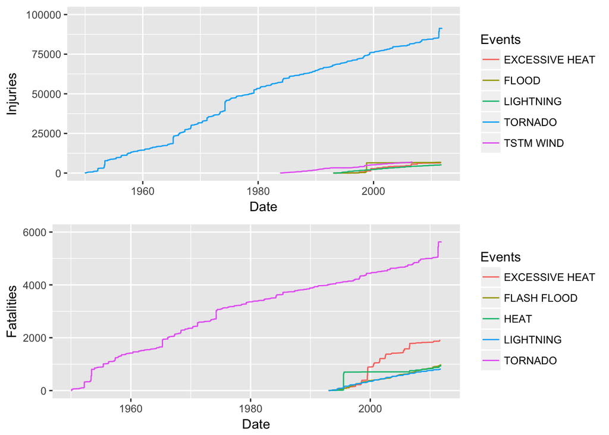

```r
# Combining fatalities and injuries in one plot
pFat<-ggplotGrob(g2)
pInf<-ggplotGrob(g1)
grid.arrange(pFat, pInf, layout_matrix = rbind(2,1))
```

## Economic Impact

#### Top 10 Events Property and Crop Damage

```r
# Transform the table into a html table
XTDam<-cbind(DamProp[1:10,], DamCrop[1:10,])
colnames(XTDam)<-c("property damage [$]", "event","crop damage[$]", "event")
ECxt<-xtable(XTDam, align = "cccrc",latex.environments="center")
print(ECxt, type = 'html', include.rownames = FALSE)
```

| property damage [$] | event | crop damage[$] | event |
| --- | --- | --- | --- |
| 144657709800.00 | FLOOD | 13972566000.00 | DROUGHT |
| 69305840000.00 | HURRICANE/TYPHOON | 5661968450.00 | FLOOD |
| 56925660480.00 | TORNADO | 5029459000.00 | RIVER FLOOD |
| 43323536000.00 | STORM SURGE | 5022113500.00 | ICE STORM |
| 16140811510.00 | FLASH FLOOD | 3025537450.00 | HAIL |
| 15727366720.00 | HAIL | 2741910000.00 | HURRICANE |
| 11868319010.00 | HURRICANE | 2607872800.00 | HURRICANE/TYPHOON |
| 7703890550.00 | TROPICAL STORM | 1421317100.00 | FLASH FLOOD |
| 6688497250.00 | WINTER STORM | 1292973000.00 | EXTREME COLD |
| 5270046260.00 | HIGH WIND | 1094086000.00 | FROST/FREEZE |

#### 1950 to November 2011: Events and related property and crop damage

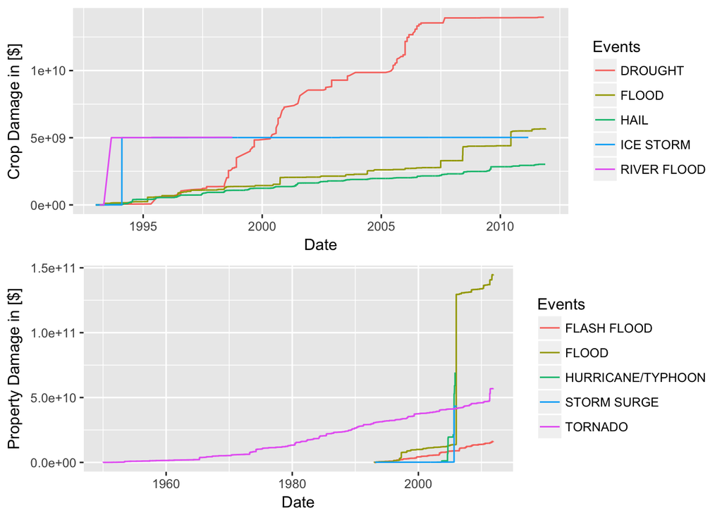

```r
# Combining property and crop damages
pProp<-ggplotGrob(g3)
pCrop<-ggplotGrob(g4)
grid.arrange(pProp, pCrop, layout_matrix = rbind(2,1))
```